# Spatially Derived Clusters

Author

Noor Sohail

Published

July 22, 2025

Keywords

## BANKSY

[BANKSY](https://www.nature.com/articles/s41588-024-01664-3) is another method for performing clustering. Unlike Seurat, BANKSY takes into account not only an individual bin’s expression pattern but also the mean and the gradient of gene expression levels in a bin’s broader neighborhood. This makes it valuable for identifying and defining spatial regions of interest.

To accomplish this, BANKSY calculates two different scores:

- Weighted mean expression of genes in a spatial neighborhood
- “Azimuthal gabor filter”, which is the “gradient of gene expression in each cell’s neighborhood”

In doing so, BANKSY is able to be flexible and not limit celltypes to *only* be located nearby one another. Even more than that, there is `lambda` value that scales the weight of each of these matrices to give the user flexibility in how strongly the spatial weights should impact clustering.

These new matrices are then concatenated to the counts matrix before running the remainder of a standard scRNA-seq workflow (dimensionality reduction, clustering, integration, etc.). Therefore, the final output of this algorithm is a modulated counts matrix that includes weighted scores that correspond to spatial domains.

```r
library(Seurat)
# remotes::install_github("prabhakarlab/Banksy")
library(Banksy)
library(SeuratWrappers)
library(tidyverse)

seurat_processed <- readRDS("data/seurat_processed.RDS")
```

### Running BANKSY

| Parameter | Description |
| --- | --- |
| `k_geom` | Number of bins to consider for the local neighborhood. Larger values will yield larger domains. |
| `lambda` | Influence of the neighborhood. Larger values yield more spatially coherent domains. The authors recommend using 0.8 to identify broader spatial domains. |
| `group` | Allows us to run BANKSY on multiple samples, enabling the function to understand that overlapping spatial locations can come from different slides. |
| `dimx`, `dimy` | The x and y coordinates of a spot on the tissue slide. |
| `split.scale` | Within-group scaling parameter, accounting for minor differences between datasets. |

To set ourselves up for success, we are going to add the spatial locations for each spot into the metadata. This will allow us to specify `dimx` and `dimy` more easily.

```r
# Store the cell barcode as a column
# Sometimes when you merge dataframes, you lose rownames
seurat_processed$cell <- rownames(seurat_processed@meta.data)

# CRC and NAT sample coordinates
coords_crc <- GetTissueCoordinates(seurat_processed,
                                   image = "P5CRC.008um")
coords_nat <- GetTissueCoordinates(seurat_processed,
                                   image = "P5NAT.008um")
coords <- rbind(coords_crc, coords_nat)
```

You may be asking, why did we have to run `GetTissueCoordinates()` twice? This is because this function will only return the coordinates for one image at a time.

```r
coords %>% head()
```

```
                                   x        y                        cell
P5CRC_s_008um_00078_00444-1 61738.62 57263.31 P5CRC_s_008um_00078_00444-1
P5CRC_s_008um_00128_00278-1 60257.61 52418.69 P5CRC_s_008um_00128_00278-1
P5CRC_s_008um_00052_00559-1 62512.22 60620.61 P5CRC_s_008um_00052_00559-1
P5CRC_s_008um_00121_00413-1 60478.41 56362.64 P5CRC_s_008um_00121_00413-1
P5CRC_s_008um_00202_00633-1 58138.03 62800.98 P5CRC_s_008um_00202_00633-1
P5CRC_s_008um_00035_00460-1 62997.04 57725.67 P5CRC_s_008um_00035_00460-1
```

Next we are going to add these coordinate sinto our metadata, this is so that we can directly call this column from the `RunBanksy()` function.

```r
seurat_processed@meta.data <- left_join(seurat_processed@meta.data, coords, by = "cell")
seurat_processed@meta.data %>% head()
```

```
  orig.ident nCount_Spatial.008um nFeature_Spatial.008um  mitoRatio
1      P5CRC                   65                     57 0.23076923
2      P5CRC                 1300                    906 0.17307692
3      P5CRC                  128                    121 0.02343750
4      P5CRC                  538                    326 0.00929368
5      P5CRC                  365                    232 0.06575342
6      P5CRC                  122                    100 0.16393443
  log10GenesPerUMI leverage.score seurat_cluster.sketched seurat_clusters
1        0.9685377     0.11825052                    <NA>            <NA>
2        0.9496410     0.81262254                    <NA>            <NA>
3        0.9884090     1.39678933                    <NA>            <NA>
4        0.9203288     0.61539562                    <NA>            <NA>
5        0.9231919     0.44573347                    <NA>            <NA>
6        0.9586074     0.09451219                    <NA>            <NA>
  seurat_cluster.projected seurat_cluster.projected.score
1                        0                      0.8541841
2                        1                      1.0000000
3                       12                      0.6813496
4                        7                      0.5658986
5                        2                      1.0000000
6                        0                      0.7949678
                         cell        x        y
1 P5CRC_s_008um_00078_00444-1 61738.62 57263.31
2 P5CRC_s_008um_00128_00278-1 60257.61 52418.69
3 P5CRC_s_008um_00052_00559-1 62512.22 60620.61
4 P5CRC_s_008um_00121_00413-1 60478.41 56362.64
5 P5CRC_s_008um_00202_00633-1 58138.03 62800.98
6 P5CRC_s_008um_00035_00460-1 62997.04 57725.67
```

But wait! Our rownames are missing! It is vital that the rownames of our Seurat object align with what is stored in `Cell()`. So we are going to add the rownames back into our metadata.

```r
# Add cell barcodes back to rownames
rownames(seurat_processed@meta.data) <- seurat_processed$cell

# Run Banksy from SeuratWrappers
seurat_banksy <- RunBanksy(seurat_processed, lambda = 0.8, verbose = T,
                           assay = 'Spatial.008um', slot = 'data', k_geom = 15,
                           dimx = 'x', dimy = 'y',
                           group = "orig.ident", split.scale = T)
```

**Warning**

Totally possible that participants run out RAM at this step. We should provide them the intermediate object at this point.

`seurat_banksy` is 10.4 GB on my system right now…

With a new `Active assay: BANKSY`

```r
seurat_banksy
```

```
An object of class Seurat
40170 features across 135798 samples within 3 assays
Active assay: BANKSY (4000 features, 0 variable features)
 2 layers present: data, scale.data
 2 other assays present: Spatial.008um, sketch
 4 dimensional reductions calculated: pca.sketch, umap.sketch, full.pca.sketch, full.umap.sketch
 2 spatial fields of view present: P5CRC.008um P5NAT.008um
```

### New BANKSY Matrix

At this point, we have our new counts matrix that includes our neighborhood weighted scores. We can see this more clearly if we investigate the `Features()` that exist in our BANKSY assay. Where teh first few features are our original counts matrix with genes.

```r
Features(seurat_banksy) %>% head()
```

```
[1] "IGHG1" "IGHM"  "SST"   "IGLC1" "INSL5" "CHGA"
```

Where we also have “new features” that are our `lambda` scaled neighborhood weighted values, with an appended `*.m0` to make the distinction clear.

```r
Features(seurat_banksy) %>% tail()
```

```
[1] "ADAM23.m0" "PNMT.m0"   "RSPO2.m0"  "HTRA3.m0"  "SLC3A1.m0" "TLR8.m0"
```

## Calculations on BANKSY matrix

With these weights, we can now run through a simplified clustering workflow - using many of the same functions we used in the previous lesson on the scRNA workflow. The only distinction here is that these values are going to be calculated on our new BANKSY count matrix.

**Exercise 1**

1. What steps/functions did we use to calculate clusters previously?

```r
# Increases the size of the default vector
options(future.globals.maxSize = 200000000000)

# PCA
seurat_banksy <- RunPCA(seurat_banksy,
                        assay = "BANKSY",
                        reduction.name = "pca.banksy",
                        features = rownames(seurat_banksy),
                        npcs = 30)

# Find k-Nearest Neighbors
seurat_banksy <- FindNeighbors(seurat_banksy,
                               reduction = "pca.banksy",
                               dims = 1:30)

# Louvain clustering
seurat_banksy <- FindClusters(seurat_banksy,
                              cluster.name = "banksy_cluster",
                              resolution = 0.65)
```

So to conserve memory, we are going to delete the BANKSY assay from our seurat object.

```r
# Change default asasy from BANKSY
DefaultAssay(seurat_banksy) <- "Spatial.008um"

# Delete BANKSY assay by setting it to NULL
seurat_banksy[["BANKSY"]] <- NULL
```

**Exercise 2**

1. Run BANKSY with a `lambda` of 0.2, how do the results differ from a value of 0.8?

## Comparing clustering methods

At this point, we have two different results for our clusters - BANKSY and RNA-based clusters. Let us take a moment to compare and contrast what the differences are between the two.

### Spatial Overlay

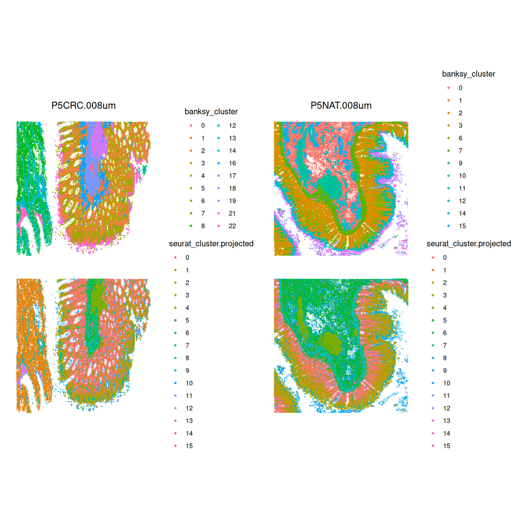

```r
SpatialDimPlot(seurat_banksy,
               group.by = c("banksy_cluster",
                            "seurat_cluster.projected"),
               pt.size.factor = 15,
               image.alpha = 0)
```

### UMAP

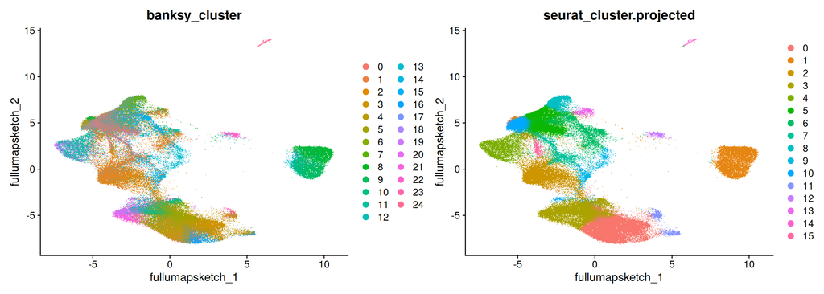

```r
DimPlot(seurat_banksy,
        group.by = c("banksy_cluster",
                     "seurat_cluster.projected"))
```

**Exercise 3**

2. What does the UMAP look like when use the BANKSY derived PCA to calculate coordinates?

Next Lesson >>

Back to Schedule